# DBiT Expression Matrix to Seurat Object for R1110C

Shuozhen Bao

2024-11-03

## DBiT Expression Matrix from zUMIs Output to Seurat Object with Images Loaded and Spots Selected

This is an R-markdown document that details a way to generate a Seurat V5 object with expression rds and spatial folder generated seperately from DBiT experiments. It realizes the functions of generalized pipeline of generating the Seurat object with expression rdsa processed by zUMIs Output from FASTQ files, stated seperately (shell + yaml by Dr. Haikuo Li), and 10x Visium format spatial folder including the experiment image information, states seperately ((Adobe Illustrator + python) or AtlasXomics browser).

Adapted from Dr. Graham Su’s scripts, originally from Cell paper doi: 10.1016/j.cell.2020.10.026

Acknowledgement to Dr. Mingyu Yang, Xing Lou, Jie Sheng, Nuoya Wang, Dr. Micha Sam Brickman Raredon

Info for the author：Workable conda_env is niches.

## Load library

Load the necessary packages.

```r
library(Seurat)
library(magrittr)
library(cowplot)
library(data.table)
library(dplyr)
library(ggplot2)
library(patchwork)
```

## Set the WD and sample names, load the original data

**Ideally, this is the only part need to be changed.**

```r
### Sample ID
project <- "/gpfs/gibbs/pi/fan/sb2723/GBM_story/RNA/"
sample <- params$sample_name
### Directory that has direct stpipeline output for gene expression matrix
dir_zUMIs_exp <- paste0(project, "01.cutadapt_zUMIs_outs/", sample, "/zUMIs_output/expression/")
list.files(dir_zUMIs_exp) # Should show *expresson folder
```

```
##  [1] "R1110C.dgecounts.rds"
##  [2] "R1110C.readcount.exon.all.loom"
##  [3] "R1110C.readcount.exon.downsampled_.loom"
##  [4] "R1110C.readcount.inex.all.loom"
##  [5] "R1110C.readcount.inex.downsampled_.loom"
##  [6] "R1110C.readcount.intron.all.loom"
##  [7] "R1110C.readcount.intron.downsampled_.loom"
##  [8] "R1110C.umicount.exon.all.loom"
##  [9] "R1110C.umicount.exon.downsampled_.loom"
## [10] "R1110C.umicount.inex.all.loom"
## [11] "R1110C.umicount.inex.downsampled_.loom"
## [12] "R1110C.umicount.intron.all.loom"
## [13] "R1110C.umicount.intron.downsampled_.loom"
```

```r
### The directory that your images or spatial folder are in
dir_img <- paste0(project, "02.10x_fmt_img/", sample)
list.files(dir_img) # Should show /spatial
```

```
## [1] "R1110C_lowres_RNA.png" "spatial"
```

```r
### Output directory
dir_out <- paste0(project,"/03.rds_gen4/", sample, "/")
if (!dir.exists(dir_out)) {dir.create(dir_out, recursive = TRUE)}

### load st-output data, we need to add spatial coordinates manually
AllCounts <- readRDS(paste0(dir_zUMIs_exp, sample, ".dgecounts.rds"))
exp_zUMIs <- AllCounts$umicount$inex$all
```

## Generate the Seurat object directly without spatial info

#### Directly generated from expression matrix

Generate Seurat object as there’s no spatial information, we will add the spatial information later.

```r
## Make the matrix format compatible
exp_zUMIs_origin <- as.matrix(exp_zUMIs)
### Generate Seurat Object with original matrix, no filtering, no spot selection
samp_zUMIs <-
  CreateSeuratObject(counts = exp_zUMIs_origin,
                     project = sample,
                     min.features = 1,
                     assay = 'Spatial')
```

#### Generate the Seurat object from expression matrix without most of mitochondrial and ribosomal RNA.

Generate the Seurat object as there’s no spatial information, we will add the spatial information later. We do this step because by applying the poly-adenylation, the mitochondrial and ribosomal RNA would be significantly increased, and that would affect the normalization process. We can calculate the percentage of genes with names contains MT, AL, H3, EEF, RPS, RPL, FP, AC, ENSM, ENSG, RNA, RN5, RN7, RNU, RNV

```r
##
df_gname <- rownames(exp_zUMIs)
df_gname_filter <- df_gname[!grepl('^(MT|AL|H3|EEF|RPS|RPL|FP|AC|ENSM|ENSG|RNA|RN5|RN7|RNU|RNV)', df_gname)] ## coordinated to gen1
df_gname_filter <- exp_zUMIs[df_gname_filter,]
allZero_cols <- colSums(df_gname_filter==0)==nrow(df_gname_filter)
df_gname_filter <- df_gname_filter[,!allZero_cols]
df_gname_filter <- as.matrix(df_gname_filter)

total_counts_original <- sum(exp_zUMIs)
total_counts_filtered <- sum(df_gname_filter)
percentage_filtered <- (1-total_counts_filtered/total_counts_original)*100
print(paste0("MT gene percentage is ", round(percentage_filtered, 2), "%"))
```

```
## [1] "MT gene percentage is 5.12%"
```

```r
### Generate the Seurat Object with MT filtered matrix, no spot selection
samp_zUMIs_filtered <-
  CreateSeuratObject(counts = df_gname_filter,
                     project = sample,
                     min.features = 1,
                     assay = 'Spatial')
```

## Construct the coordinates and load the image info

```r
##### Transform the coordinates to barcode sequences so the image info can be used
barcodes50_file <- "/vast/palmer/pi/fan/sb2723/00.database/barcodes-AB.xls"
barcode50 <- read.table(barcodes50_file, header = FALSE, stringsAsFactors = FALSE)
colnames(barcode50) <- c("nucleotide_name", "img.x.cord", "img.y.cord")
barcode50$x.y.cord <- paste0(barcode50$img.x.cord, "x",barcode50$img.y.cord)
name_mapping <- setNames(barcode50$x.y.cord, barcode50$nucleotide_name)
```

## Add the nucleotide name to metadata

```r
### Unfiltered
spatial_barcodes <- Cells(samp_zUMIs)
name_mapping_zUMIs <- name_mapping[Cells(samp_zUMIs)]
samp_zUMIs@meta.data$x.y.coord <- name_mapping_zUMIs

### Same process for the filtered object
spatial_barcodes_filtered <- Cells(samp_zUMIs_filtered)
name_mapping_zUMIs_filtered <- name_mapping[spatial_barcodes_filtered]
samp_zUMIs_filtered@meta.data$x.y.coord <- name_mapping_zUMIs_filtered
```

## Load images and add the spatial information

```r
### Load the images in the spatial folder generated by python
img <- Read10X_Image(image.dir = paste0(dir_img, "/spatial"), filter.matrix = TRUE)
image_barcodes <- img@boundaries$centroids@cells
common_barcodes <- intersect(spatial_barcodes,image_barcodes)
common_barcodes_filtered <- intersect(spatial_barcodes_filtered,image_barcodes)
img_origin <- img[common_barcodes, ]
img_noMT <- img[common_barcodes_filtered, ]
```

```r
### Add the images to the Seurat object
samp_zUMIs[[sample]] <- img_origin

samp_zUMIs_ontissue <- subset(samp_zUMIs, cells = common_barcodes)
samp_zUMIs_ontissue[[sample]] <- img_origin
names(samp_zUMIs_ontissue@meta.data)
```

```
## [1] "orig.ident"       "nCount_Spatial"   "nFeature_Spatial" "x.y.coord"
```

```r
samp_zUMIs_filtered[[sample]] <- img_noMT

samp_zUMIs_filtered_ontissue <- subset(samp_zUMIs_filtered, cells = common_barcodes_filtered)
samp_zUMIs_filtered_ontissue[[sample]] <- img_noMT
names(samp_zUMIs_filtered_ontissue@meta.data)
```

```
## [1] "orig.ident"       "nCount_Spatial"   "nFeature_Spatial" "x.y.coord"
```

## QC plot and Save the files

```r
p1 <- VlnPlot(samp_zUMIs_ontissue, features = "nCount_Spatial", pt.size = 0.1) + NoLegend()
p2 <- SpatialFeaturePlot(samp_zUMIs_ontissue, features = "nCount_Spatial",pt.size.factor = 2,stroke = 0, image.alpha = 1) + theme(legend.position = "right")
p3 <- VlnPlot(samp_zUMIs_ontissue, features = "nFeature_Spatial", pt.size = 0.1) + NoLegend()
p4 <- SpatialFeaturePlot(samp_zUMIs_ontissue, features = "nFeature_Spatial",pt.size.factor = 2,stroke = 0, image.alpha = 1) + theme(legend.position = "right")

png(filename=paste0(dir_out, sample, '_original_QC_on_tissue.png'), width = 8,height = 8,units = 'in',res=300)
plotA <- (p1 | p2)/ (p3 | p4)
plotA + plot_annotation(
  title = paste0(sample, '_original_QC_on_tissue'),
)
dev.off()
```

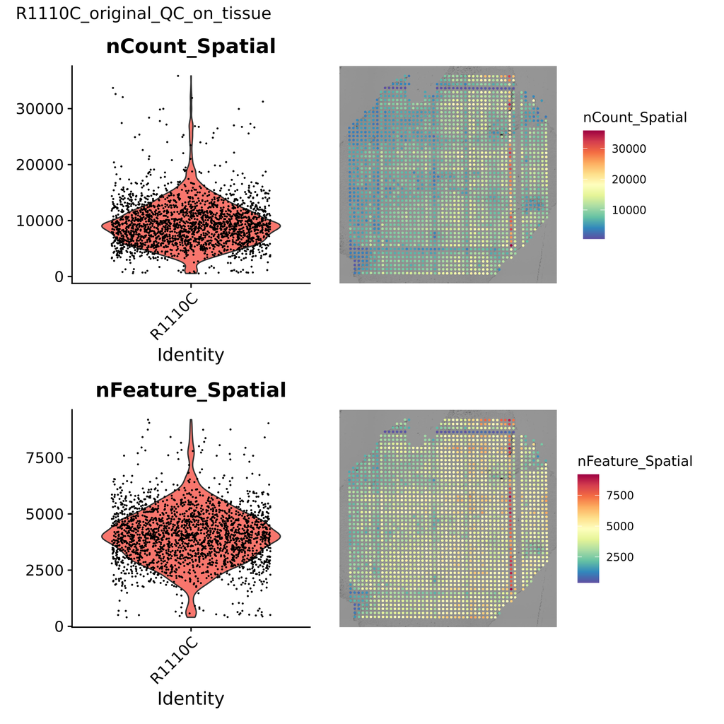

```r
knitr::include_graphics(paste0(dir_out, sample, '_original_QC_on_tissue.png'))
```

```r
p5 <- VlnPlot(samp_zUMIs_filtered_ontissue, features = "nCount_Spatial", pt.size = 0.1) + NoLegend()
p6 <- SpatialFeaturePlot(samp_zUMIs_filtered_ontissue, features = "nCount_Spatial",pt.size.factor = 2,stroke = 0, image.alpha = 1) + theme(legend.position = "right")
png(filename=paste0(dir_out, sample, '_noMT_QC_on_tissue.png'), width = 8,height = 4,units = 'in',res=300)
p7 <- VlnPlot(samp_zUMIs_filtered_ontissue, features = "nFeature_Spatial", pt.size = 0.1) + NoLegend()
p8 <- SpatialFeaturePlot(samp_zUMIs_filtered_ontissue, features = "nFeature_Spatial",pt.size.factor = 2,stroke = 0, image.alpha = 1) + theme(legend.position = "right")
png(filename=paste0(dir_out, sample, '_noMT_QC_on_tissue.png'), width = 8,height = 8,units = 'in',res=300)
plotB <- (p5 | p6)/(p7 | p8)
plotB + plot_annotation(
  title = paste0(sample, '_noMT_QC_on_tissue'),
)
dev.off()
```

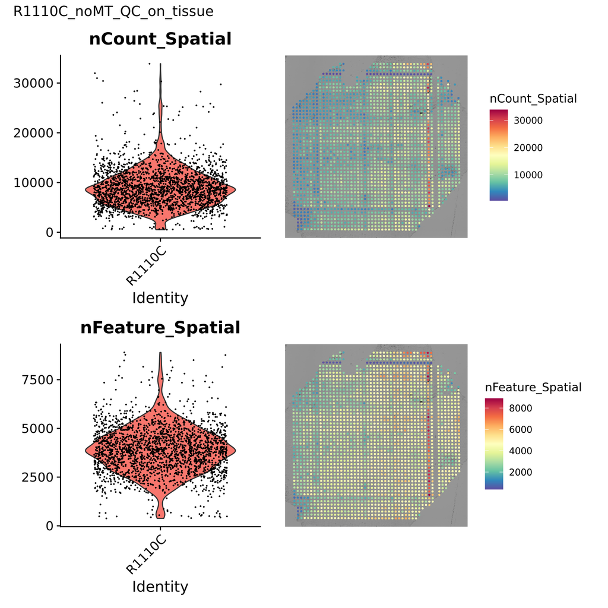

```r
knitr::include_graphics(paste0(dir_out, sample, '_noMT_QC_on_tissue.png'))
```

```r
saveRDS(samp_zUMIs, file = paste0(dir_out, sample, '_gen4_01_original.rds'))
saveRDS(samp_zUMIs_filtered, file = paste0(dir_out, sample, '_gen4_02_noMT.rds'))

saveRDS(samp_zUMIs_ontissue, file = paste0(dir_out, sample, '_gen4_01_original_on_tissue.rds'))
saveRDS(samp_zUMIs_filtered_ontissue, file = paste0(dir_out, sample, '_gen4_02_noMT_on_tissue.rds'))
```